# Plotting in Spatial Statistics

Yang Li

2026-05-22

# Base R versus ggplot2

Base R is great for quick exploration and simple graphics.

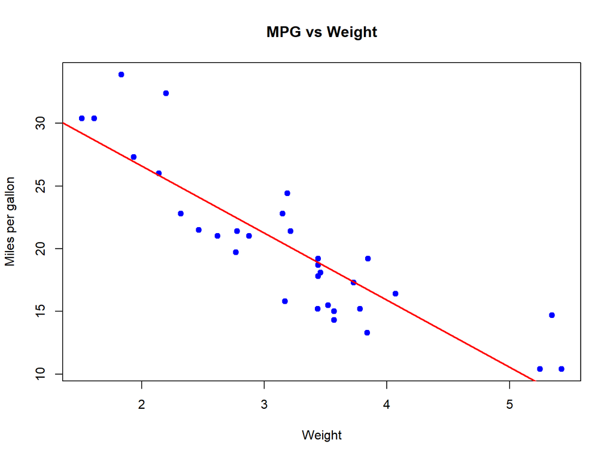

```r
plot(mtcars$wt, mtcars$mpg,
     xlab = "Weight",
     ylab = "Miles per gallon",
     main = "MPG vs Weight",
     pch = 19,
     col = "blue")

abline(lm(mpg ~ wt, data = mtcars), col = "red", lwd = 2)
```

`ggplot2` uses the grammar of graphics idea: you define the data, map variables to aesthetics, then add layers. It is usually better for polished, complex, and reproducible visualizations.

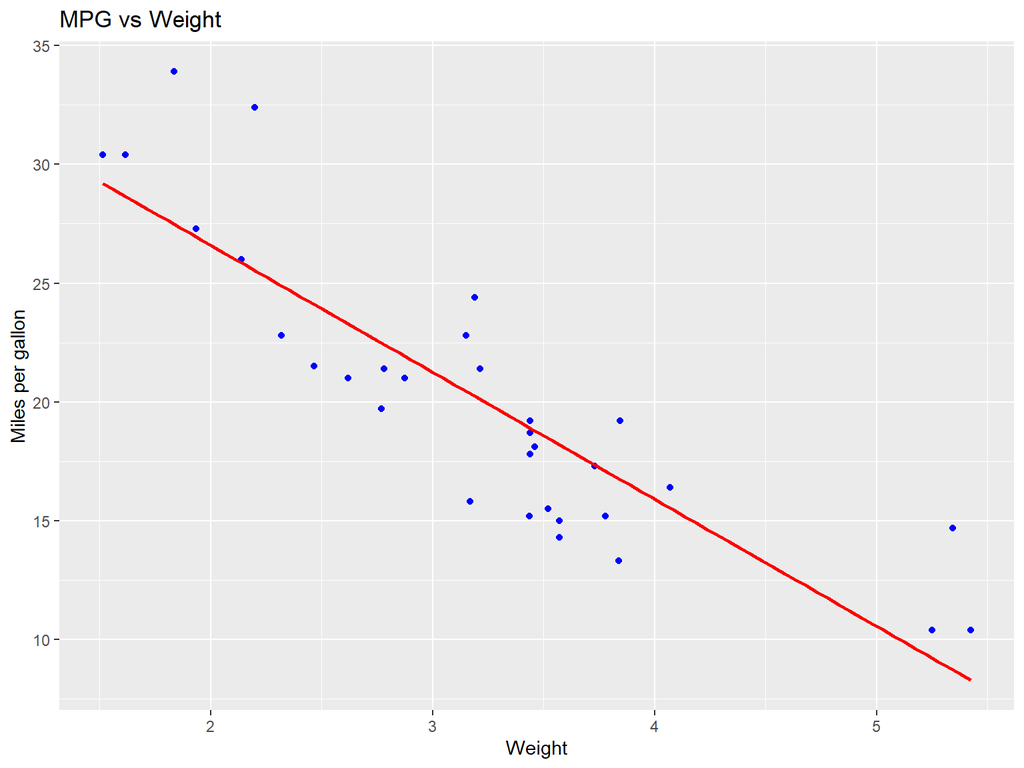

```r
library(ggplot2)

ggplot(mtcars, aes(x = wt, y = mpg)) +
  geom_point(color = "blue") +
  geom_smooth(method = "lm", se = FALSE, color = "red") +
  labs(
    title = "MPG vs Weight",
    x = "Weight",
    y = "Miles per gallon"
  )
```

# Make a Static Map of a Country

Here are some packages for map-related plotting.

```r
library(sf)
library(sp)
library(gstat)
library(dplyr)
library(mapview)
library(spatstat.data)
library(spatstat.geom)
library(spatstat.explore)
library(rnaturalearth)
```

# World Map

We use `rnaturalearth` package for map details. This package

- provides convenient access to Natural Earth map data directly from R;
- contains including country borders, coastlines, and other geographic layers;
- works with packages like ggplot2, sf seamlessly.

## Base R

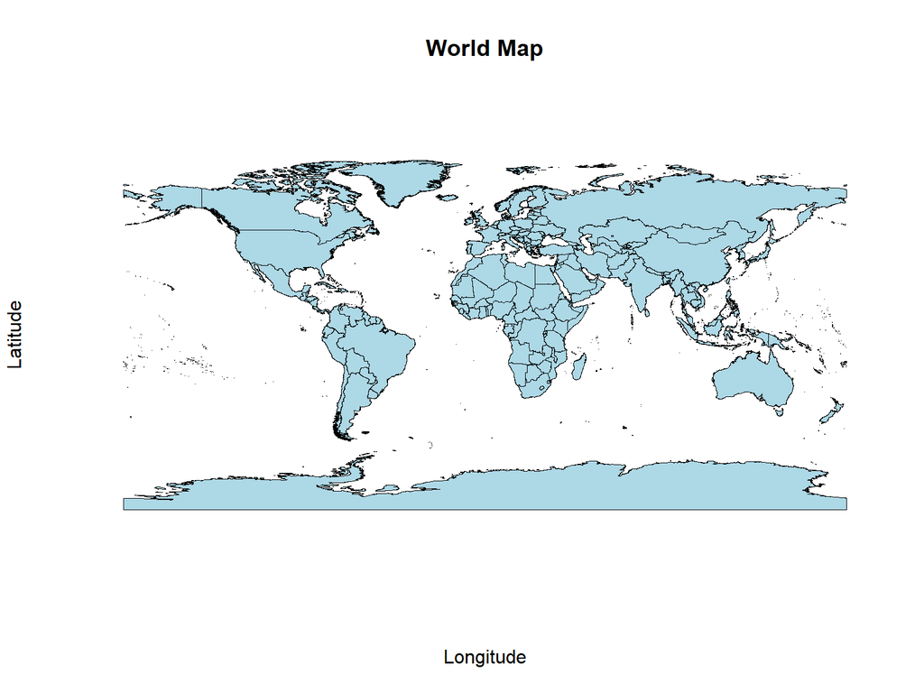

```r
world <- ne_countries(scale = 10, returnclass = "sf")
plot(
  world$geometry,
  col = "lightblue",      # fill color
  border = "black",      # boundary color
  lwd = 0.5,              # boundary line width
  main = "World Map",
  xlab = "Longitude",
  ylab = "Latitude"
)
```

`scale` controls the resolution/detail level of the map data you download.

- `small` or 110: low resolution, faster, less detail
- `medium` or 50: moderate detail
- `large` or 10: high resolution, more detailed coastlines and borders

## ggplot2

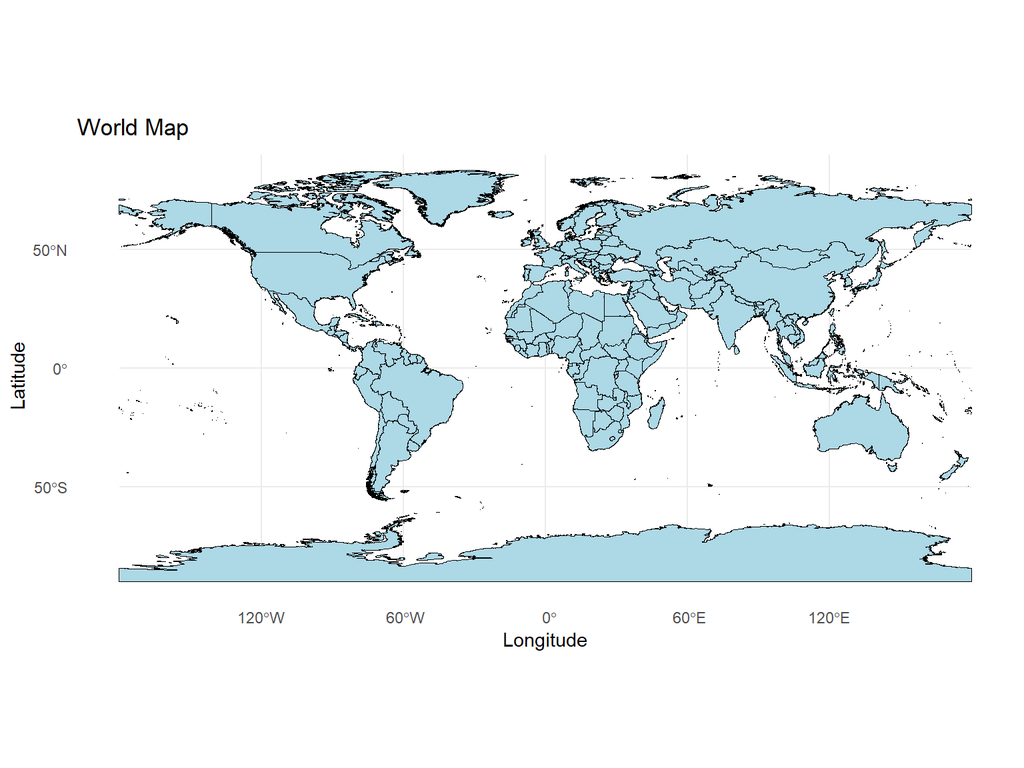

```r
ggplot(world) +
  geom_sf(fill = "lightblue", color = "black") +
  coord_sf() +
  theme_minimal() +
  labs(
    title = "World Map",
    x = "Longitude",
    y = "Latitude"
  )
```

# Continent Map

Get the polygons of Africa.

```r
africa <- ne_countries(continent = "africa", returnclass = "sf")
```

## Base R

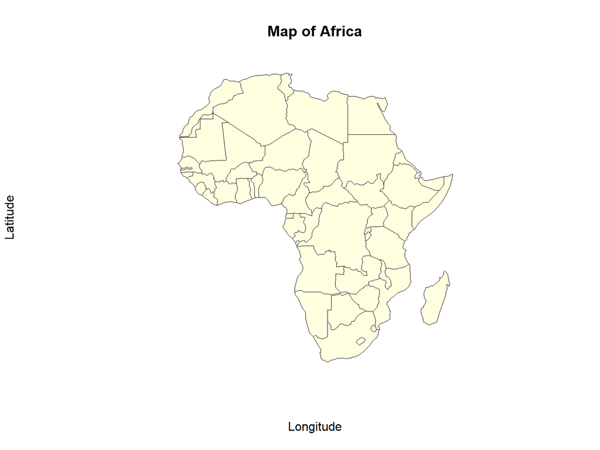

```r
plot(
  africa$geometry,
  col = "lightyellow",      # fill color
  border = "black",      # boundary color
  lwd = 0.5,              # boundary line width
  main = "Map of Africa",
  xlab = "Longitude",
  ylab = "Latitude"
)
```

## ggplot2

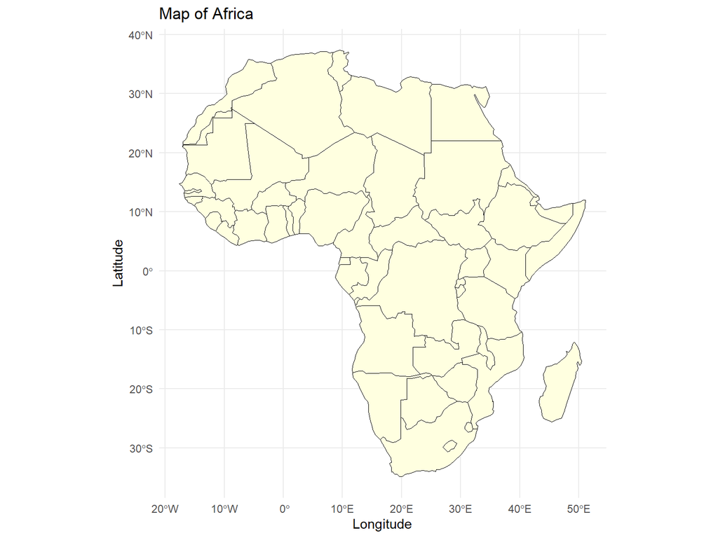

```r
ggplot(africa) +
  geom_sf(fill = "lightyellow", color = "black") +
  coord_sf() +
  theme_minimal() +
  labs(
    title = "Map of Africa",
    x = "Longitude",
    y = "Latitude"
  )
```

# Country Map

```r
usa <- ne_countries(
  country = "United States of America",
  returnclass = "sf"
)
```

```r
world <- ne_countries(returnclass = "sf")
head(sort(unique(world$name)))
```

```
## [1] "Afghanistan" "Albania"     "Algeria"     "Angola"      "Antarctica"
## [6] "Argentina"
```

## Base R

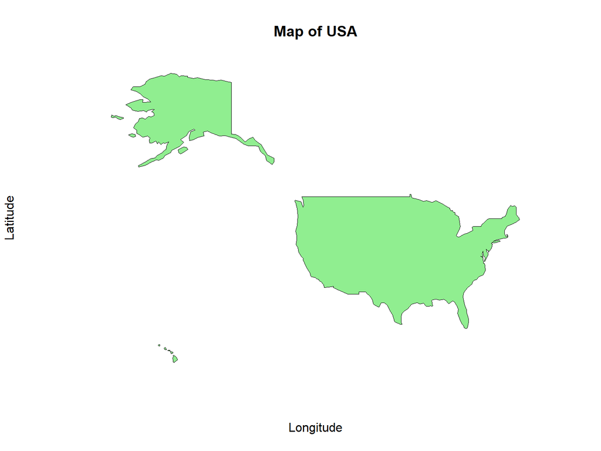

```r
plot(usa$geometry,
  col = "lightgreen",      # fill color
  border = "black",      # boundary color
  lwd = 0.5,              # boundary line width
  main = "Map of USA",
  xlab = "Longitude",
  ylab = "Latitude"
)
```

## ggplot2

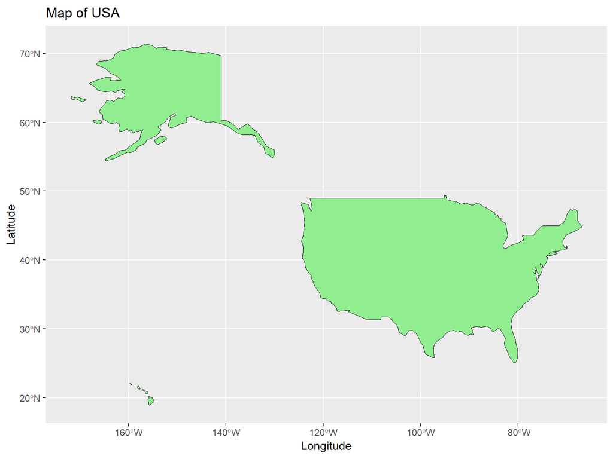

```r
ggplot(usa) +
  geom_sf(fill = "lightgreen", color = "black") +
  coord_sf() +
  labs(
    title = "Map of USA",
    x = "Longitude",
    y = "Latitude"
  )
```

# States in the US

```r
states <- ne_states(
  country = "United States of America",
  returnclass = "sf"
)
```

You can use other countries as well, “Mexico”, “France”, etc.

## Base R

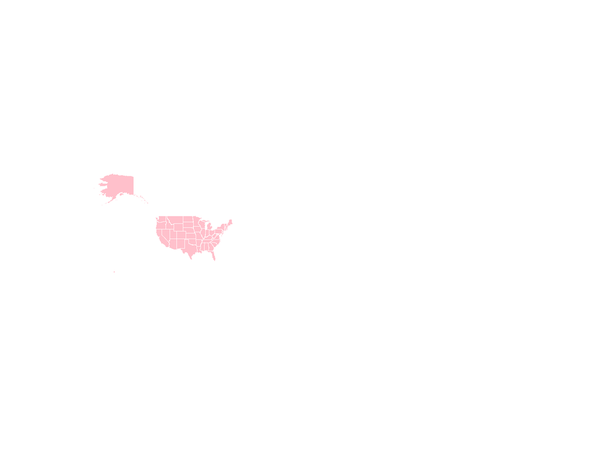

```r
plot(
  states$geometry,
  col = "pink",
  border = "white",
  lwd = 0.5
)
```

What happened?

## Only Lower 48 States

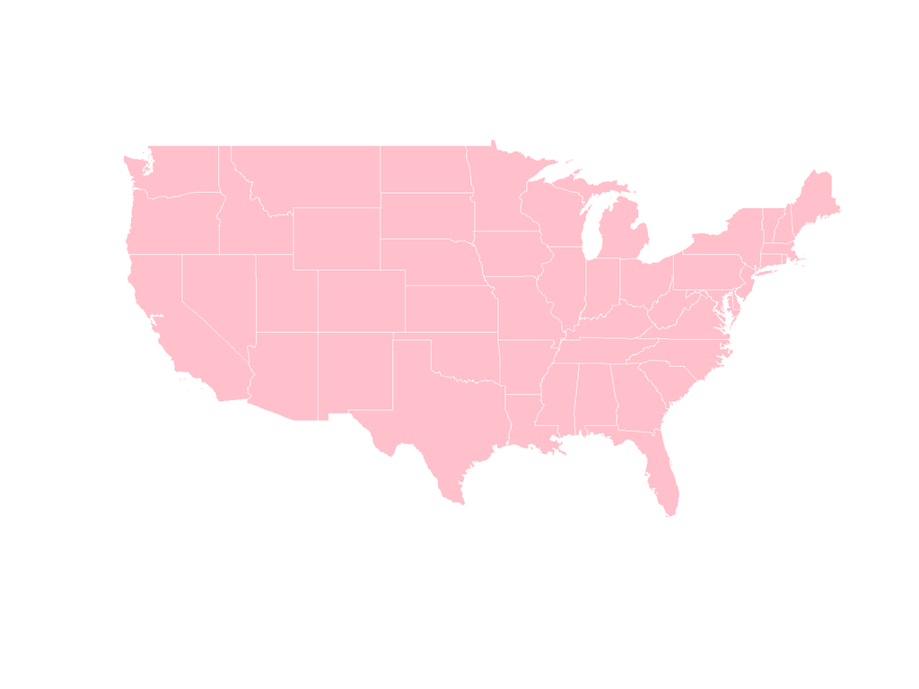

```r
lower48 <- states[
  !(states$name %in% c("Alaska", "Hawaii", "Puerto Rico")),
]

plot(
  lower48$geometry,
  col = "pink",
  border = "white",
  lwd = 0.5
)
```

## ggplot2

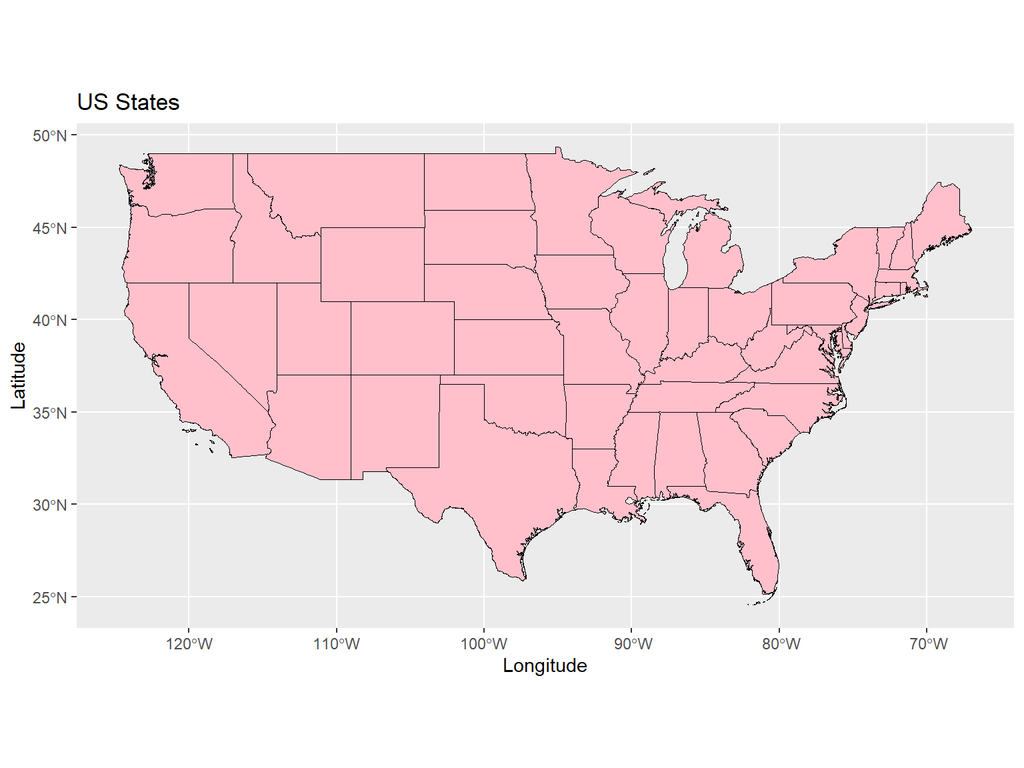

```r
ggplot(lower48) +
  geom_sf(fill = "pink", color = "black") +
  coord_sf() +
  labs(
    title = "US States",
    x = "Longitude",
    y = "Latitude"
  )
```

# Color Based On Conditions

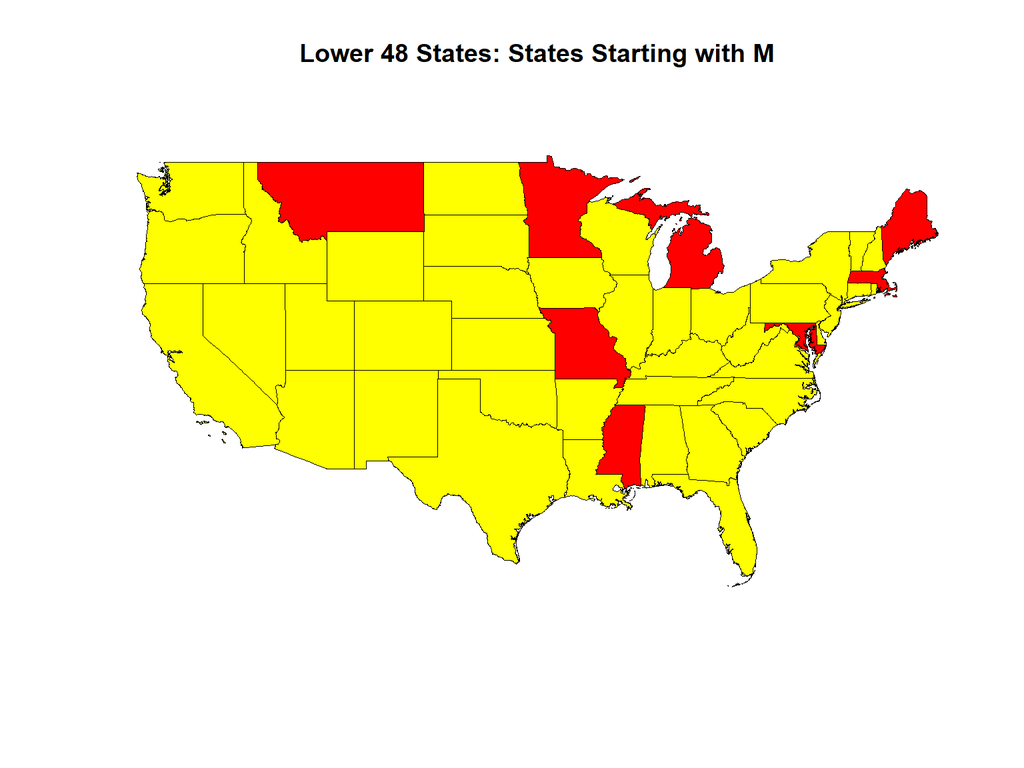

```r
state_colors <- ifelse(
  grepl("^M", lower48$name),
  "red",
  "yellow"
)

plot(
  lower48$geometry,
  col = state_colors,
  border = "black",
  lwd = 0.5,
  main = "Lower 48 States: States Starting with M"
)
```

**States starting with letter “M”**

```r
lower48$name[grepl("^M", lower48$name)]
```

```
## [1] "Montana"       "Minnesota"     "Michigan"      "Maine"
## [5] "Mississippi"   "Maryland"      "Massachusetts" "Missouri"
```

# Choropleth Map

A **choropleth map** is a map where regions are colored or shaded according to the value of a variable. Here we use North Carolina Sudden Infant Death Syndrome (SIDS) data at two time periods (1974-78 and 1979-84).

```r
nc <- st_read(system.file("shape/nc.shp", package = "sf"), quiet = TRUE)
head(nc)
```

```
## Simple feature collection with 6 features and 14 fields
## Geometry type: MULTIPOLYGON
## Dimension:     XY
## Bounding box:  xmin: -81.74107 ymin: 36.07282 xmax: -75.77316 ymax: 36.58965
## Geodetic CRS:  NAD27
##    AREA PERIMETER CNTY_ CNTY_ID        NAME  FIPS FIPSNO CRESS_ID BIR74 SID74
## 1 0.114     1.442  1825    1825        Ashe 37009  37009        5  1091     1
## 2 0.061     1.231  1827    1827   Alleghany 37005  37005        3   487     0
## 3 0.143     1.630  1828    1828       Surry 37171  37171       86  3188     5
## 4 0.070     2.968  1831    1831   Currituck 37053  37053       27   508     1
## 5 0.153     2.206  1832    1832 Northampton 37131  37131       66  1421     9
## 6 0.097     1.670  1833    1833    Hertford 37091  37091       46  1452     7
##   NWBIR74 BIR79 SID79 NWBIR79                       geometry
## 1      10  1364     0      19 MULTIPOLYGON (((-81.47276 3...
## 2      10   542     3      12 MULTIPOLYGON (((-81.23989 3...
## 3     208  3616     6     260 MULTIPOLYGON (((-80.45634 3...
## 4     123   830     2     145 MULTIPOLYGON (((-76.00897 3...
## 5    1066  1606     3    1197 MULTIPOLYGON (((-77.21767 3...
## 6     954  1838     5    1237 MULTIPOLYGON (((-76.74506 3...
```

```r
nc <- nc |>
  mutate(
    SID_rate_74 = 1000 * SID74 / BIR74,
    SID_rate_79 = 1000 * SID79 / BIR79
  )
```

## Base R

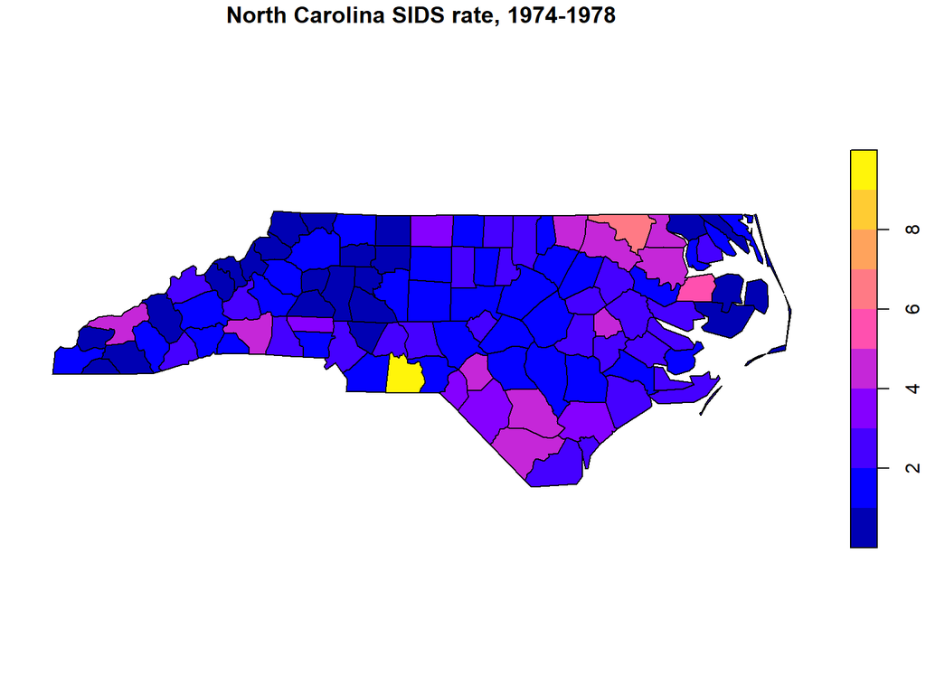

```r
plot(
  nc["SID_rate_74"],
  main = "North Carolina SIDS rate, 1974-1978",
  key.pos = 4
)
```

## ggplot2

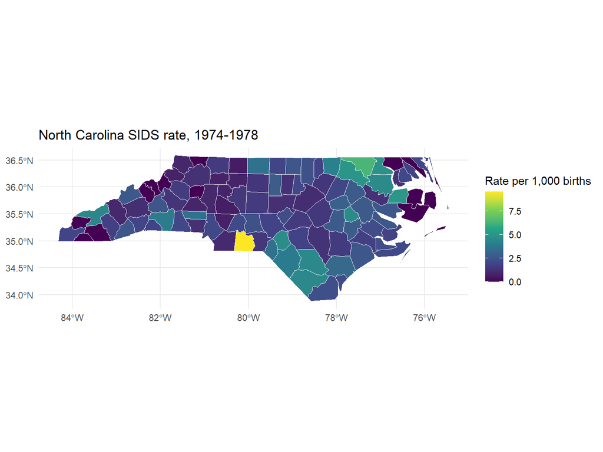

```r
ggplot(nc) +
  geom_sf(aes(fill = SID_rate_74), color = "white", linewidth = 0.2) +
  scale_fill_viridis_c() +
  theme_minimal() +
  labs(
    title = "North Carolina SIDS rate, 1974-1978",
    fill = "Rate per 1,000 births"
  )
```

The `mapview` package is an R package for creating interactive maps quickly and easily.

## Interactive Map

```r
mapview(nc,
  zcol = "SID_rate_74",
  layer.name = "SIDS rate, 1974-1978"
)
```

[interactive chart not shown]

# County-Level Map

`tigris` is an R package that allows users to directly download and use TIGER/Line and cartographic boundary shapefiles from the US Census Bureau in R.

- `counties`: download a US Counties shapefile into R, and optionally subset by state
- `states`: download shapefile for all states into R

```r
library(tigris)
fl_counties <- counties(state = "FL", cb = TRUE, class = "sf", progress_bar = FALSE)
```

Here are some files with data for counties in Florida.

```r
covid <- read.csv("https://yangli-stat.github.io/data/COVID19CasesYearly.csv", header=TRUE)
ehi <- read.csv("https://yangli-stat.github.io/data/florida_hardship_index.csv", header=TRUE)
fl_pop <- read.csv("https://yangli-stat.github.io/data/FL-Population.csv", header=TRUE)
fl_pop$POP <- as.numeric(gsub(",", "", fl_pop$POP))
```

```r
ehi_small <- ehi[, c("NAME", "NORMALIZED_EHI")]
ehi_covid <- left_join(ehi_small, covid, by="NAME")
fl_data <- fl_counties |>
  left_join(ehi_covid, by = "NAME") |>
    left_join(fl_pop, by = "NAME")
head(fl_data)
```

```
## Simple feature collection with 6 features and 21 fields
## Geometry type: MULTIPOLYGON
## Dimension:     XY
## Bounding box:  xmin: -86.39736 ymin: 27.82206 xmax: -80.44697 ymax: 30.99448
## Geodetic CRS:  NAD83
##   STATEFP COUNTYFP COUNTYNS        GEOIDFQ GEOID      NAME         NAMELSAD
## 1      12      007 00303634 0500000US12007 12007  Bradford  Bradford County
## 2      12      009 00295749 0500000US12009 12009   Brevard   Brevard County
## 3      12      131 00295727 0500000US12131 12131    Walton    Walton County
## 4      12      053 00295751 0500000US12053 12053  Hernando  Hernando County
## 5      12      047 00295736 0500000US12047 12047  Hamilton  Hamilton County
## 6      12      065 00295733 0500000US12065 12065 Jefferson Jefferson County
##   STUSPS STATE_NAME LSAD      ALAND     AWATER NORMALIZED_EHI covid2020
## 1     FL    Florida   06  761368539   16898784       37.38802      2223
## 2     FL    Florida   06 2628752387 1403951179       10.77354     20963
```

[output cut: 18 more lines]

### Base R

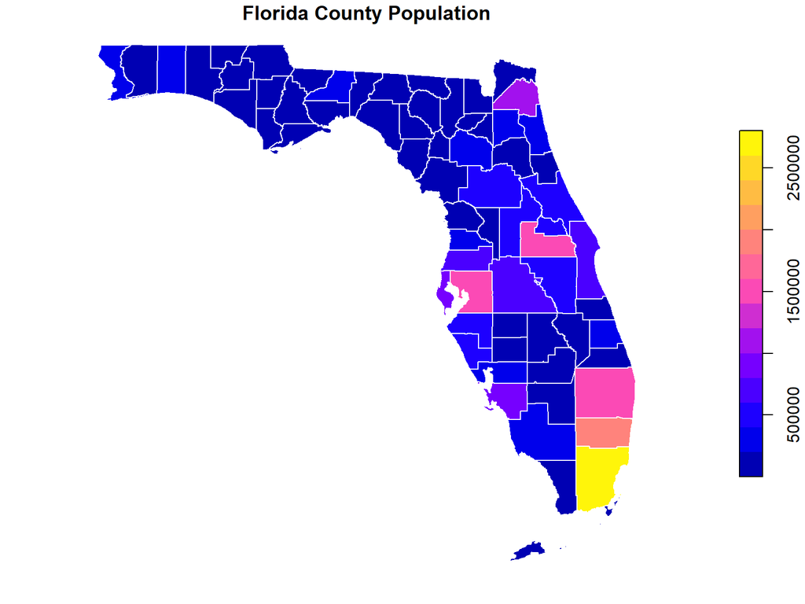

```r
plot(
  fl_data["POP"],
  border = "white",
  main = "Florida County Population"
)
```

### ggplot2

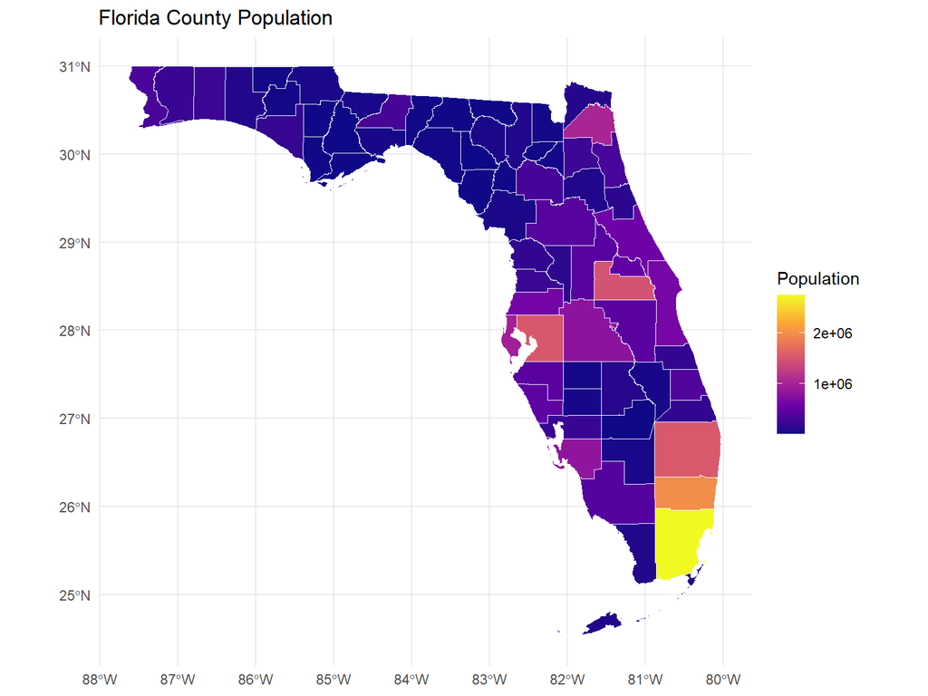

```r
ggplot(fl_data) +
  geom_sf(aes(fill = POP), color = "white") +
  scale_fill_viridis_c(option = "plasma", na.value = "grey80") +
  labs(title = "Florida County Population", fill = "Population") +
  theme_minimal()
```

### Interactive Map with mapview

```r
mapview(fl_data, zcol = "POP", layer.name="Pop")
```

[interactive chart not shown]

# Add Some Locations on the Map

## Fixed locations

```r
dots <- data.frame(
  name = c("A", "B", "C"),
  lon = c(-80.19, -82.46, -81.66),
  lat = c(25.76, 27.95, 30.33)
)

dots_sf <- st_as_sf(
  dots,
  coords = c("lon", "lat"),
  crs = 4326
)
```

### Base R

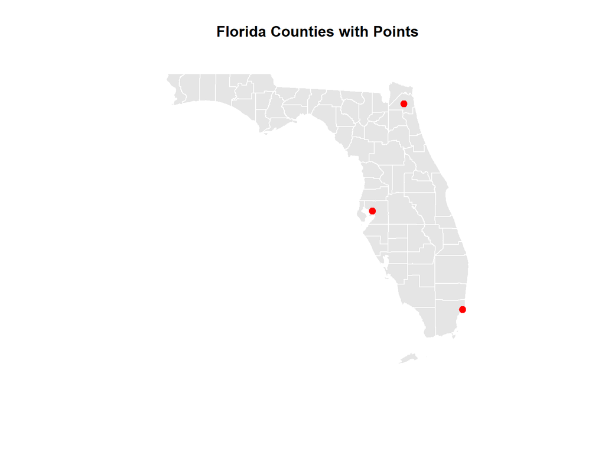

```r
plot(
  fl_counties$geometry,
  col = "gray90",
  border = "white",
  main = "Florida Counties with Points"
)

plot(
  dots_sf$geometry,
  add = TRUE,
  pch = 19,
  col = "red",
  cex = 1.2
)
```

### ggplot2

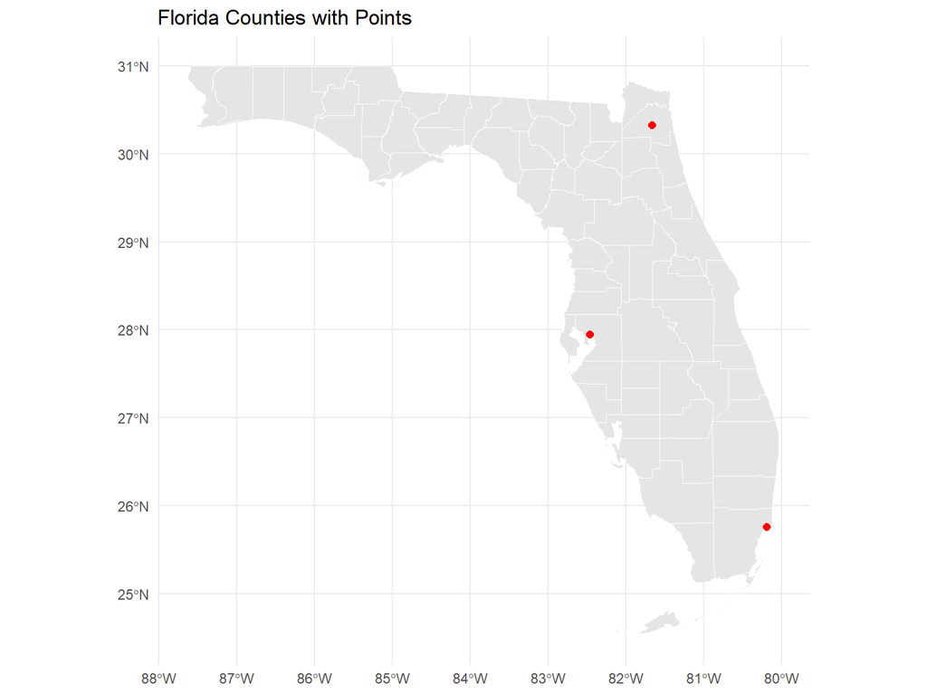

```r
ggplot() +
  geom_sf(data = fl_counties, fill = "gray90", color = "white") +
  geom_sf(data = dots_sf, color = "red", size = 2) +
  theme_minimal() +
  labs(title = "Florida Counties with Points")
```

## Random Locations

Randomly generate 100 location within Florida

```r
fl_state <- st_union(fl_counties)  # Combine several feature geometries into one

random_dots <- st_sample(
  fl_state,
  size = 100
)

random_dots <- st_sf(geometry = random_dots)
```

### Base R

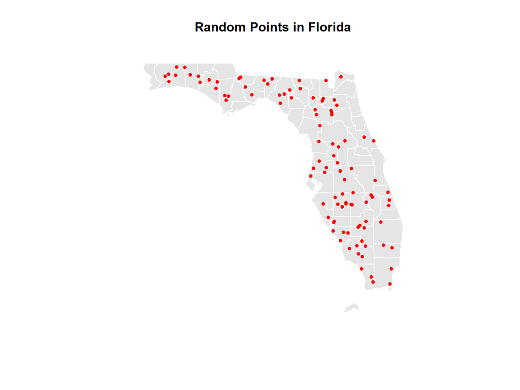

```r
plot(
  fl_counties$geometry,
  col = "gray90",
  border = "white",
  main = "Random Points in Florida"
)

plot(
  random_dots$geometry,
  add = TRUE,
  pch = 19,
  col = "red",
  cex = 0.7
)
```

### ggplot2

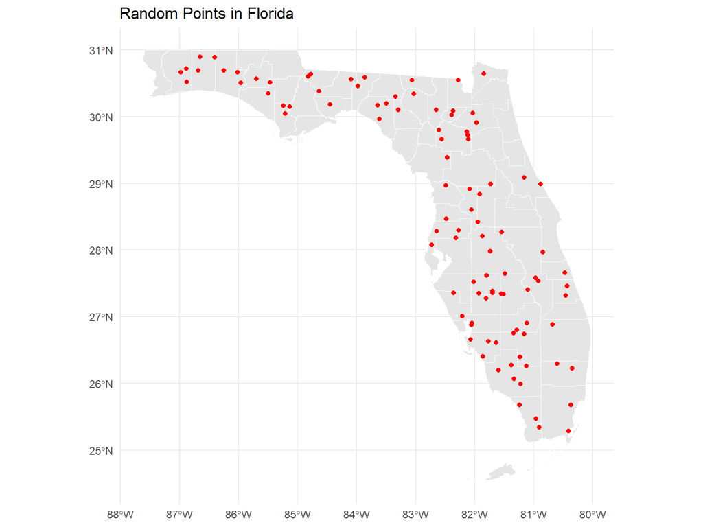

```r
ggplot() +
  geom_sf(data = fl_counties, fill = "gray90", color = "white") +
  geom_sf(data = random_dots, color = "red", size = 1.5) +
  theme_minimal() +
  labs(title = "Random Points in Florida")
```